# Animated Slope and Log-linearity plot

# Introduction

This notebook will produce an animated plot.

# Preparation

```r
pacman::p_load(
  lubridate,
  here,
  ggrepel,
  tidyverse,
  gganimate,
  wbstats
  )
```

Now use time series and link to file

Now use time series and link to file

```r
url_confirmed <- "https://raw.githubusercontent.com/CSSEGISandData/COVID-19/master/csse_covid_19_data/csse_covid_19_time_series/time_series_covid19_confirmed_global.csv"

url_deaths <- "https://raw.githubusercontent.com/CSSEGISandData/COVID-19/master/csse_covid_19_data/csse_covid_19_time_series/time_series_covid19_deaths_global.csv"


url_recovered <- "https://raw.githubusercontent.com/CSSEGISandData/COVID-19/master/csse_covid_19_data/csse_covid_19_time_series/time_series_covid19_recovered_global.csv"
```

```r
n_confirmed <-
  read_csv(url_confirmed) %>%
    select(-Lat, -Long) %>%
    rename(
      lower = `Province/State`,
      higher = `Country/Region`
    ) %>%
    gather(-lower, -higher, key = "date", value = "n_confirmed") %>%
    mutate(date = mdy(date))
n_recovered <-
  read_csv(url_recovered) %>%
    select(-Lat, -Long) %>%
    rename(
      lower = `Province/State`,
      higher = `Country/Region`
    ) %>%
    gather(-lower, -higher, key = "date", value = "n_recovered") %>%
    mutate(date = mdy(date))
n_deaths <-
  read_csv(url_deaths) %>%
    select(-Lat, -Long) %>%
    rename(
      lower = `Province/State`,
      higher = `Country/Region`
    ) %>%
    gather(-lower, -higher, key = "date", value = "n_deaths") %>%
    mutate(date = mdy(date))
tidied_data <-
  reduce(.x = list(n_confirmed, n_recovered, n_deaths), full_join, by = c("lower", "higher", "date")) %>%
    gather(key = "type", value = "n", n_confirmed:n_deaths) %>%
    mutate(type = str_replace(type, pattern = "^n_", "")) %>%
    replace_na(list(n = 0))
```

```r
big_case_countries <-
  tidied_data %>%
    filter(type == "confirmed") %>%
    group_by(date, higher) %>%
    summarise(n = sum(n)) %>%
    ungroup()  %>%
    filter(date == max(date)) %>%
    arrange(desc(n)) %>%
    filter(n > 100) %>%
    pull(higher)
```

1. Those countries where there have been at least 100 cases for at least 5 days.
2. For each of these I want to extract
   1. The number of cases
   2. The gradient
   3. The log linearity.
3. I would like a label too (Country code)
4. Let’s size by population too
5. And colour by continent

Country to continent lookup

```r
dta_country_continent_lookup <- read_csv("https://datahub.io/JohnSnowLabs/country-and-continent-codes-list/r/country-and-continent-codes-list-csv.csv") %>%
  mutate(
    Continent_Code = case_when(
      is.na(Continent_Code) ~ "NA", # NA was mis-parsed as NA rather than "NA" - North America!
      TRUE                  ~ Continent_Code
    )
  )
# There's some matching work required
tidied_country_continent_lookup <-
  dta_country_continent_lookup %>%
    mutate(
      stripped_name = map_chr(Country_Name, str_extract, pattern = "^[^,]+"),
      special_name  = case_when(
        Country_Name == "Taiwan"                                        ~ "Taiwan*",
        Country_Name == "Korea, Democratic People's Republic of"        ~ "Korea, North",
        Country_Name == "Korea, Republic of"                            ~ "Korea, South",
        TRUE                                                            ~ NA_character_
      ),
      name_to_match = coalesce(special_name, stripped_name) # First special name, then if NA stripped name
    )

tidied_country_continent_lookup
```

| Continent_Name | Continent_Code | Country_Name | Two_Letter_Country_Code | Three_Letter_Country_Code | Country_Number | stripped_name | special_name | name_to_match |
| --- | --- | --- | --- | --- | --- | --- | --- | --- |
| Asia | AS | Afghanistan, Islamic Republic of | AF | AFG | 4 | Afghanistan | NA | Afghanistan |
| Europe | EU | Albania, Republic of | AL | ALB | 8 | Albania | NA | Albania |
| Antarctica | AN | Antarctica (the territory South of 60 deg S) | AQ | ATA | 10 | Antarctica (the territory South of 60 deg S) | NA | Antarctica (the territory South of 60 deg S) |
| Africa | AF | Algeria, People's Democratic Republic of | DZ | DZA | 12 | Algeria | NA | Algeria |
| Oceania | OC | American Samoa | AS | ASM | 16 | American Samoa | NA | American Samoa |
| Europe | EU | Andorra, Principality of | AD | AND | 20 | Andorra | NA | Andorra |
| Africa | AF | Angola, Republic of | AO | AGO | 24 | Angola | NA | Angola |
| North America | NA | Antigua and Barbuda | AG | ATG | 28 | Antigua and Barbuda | NA | Antigua and Barbuda |
| Europe | EU | Azerbaijan, Republic of | AZ | AZE | 31 | Azerbaijan | NA | Azerbaijan |
| Asia | AS | Azerbaijan, Republic of | AZ | AZE | 31 | Azerbaijan | NA | Azerbaijan |

[output cut: 252 more lines]

And population (using wbstats package)

```r
pop_wb <- wb(indicator = "SP.POP.TOTL")
```

```
`wb()` is deprecated as of wbstats 1.0.0.
Please use `wb_data()` instead.
```

```r
code_population <-
  pop_wb %>%
    mutate(date = as.numeric(date)) %>%
    group_by(iso3c) %>%
    filter(date == max(date)) %>%
    ungroup() %>%
    select(country_code = iso3c, population = value)

code_population
```

| country_code | population |
| --- | --- |
| ARB | 427870270 |
| CSS | 7401383 |
| CEB | 102378579 |
| EAR | 3290290613 |
| EAS | 2340628292 |
| EAP | 2093675040 |
| TEA | 2067984156 |
| EMU | 342597698 |
| ECS | 921140092 |
| ECA | 399404587 |

[output cut: 253 more lines]

```r
NA
```

So, let’s try to match on this

```r
country_tidied_data <-
  tidied_data %>%
  group_by(higher, date, type) %>%
  summarise(n = sum(n)) %>%
  ungroup() %>%
  rename(country = higher)
country_tidied_data
```

| country | date | type | n |
| --- | --- | --- | --- |
| Afghanistan | 2020-01-22 | confirmed | 0 |
| Afghanistan | 2020-01-22 | deaths | 0 |
| Afghanistan | 2020-01-22 | recovered | 0 |
| Afghanistan | 2020-01-23 | confirmed | 0 |
| Afghanistan | 2020-01-23 | deaths | 0 |
| Afghanistan | 2020-01-23 | recovered | 0 |
| Afghanistan | 2020-01-24 | confirmed | 0 |
| Afghanistan | 2020-01-24 | deaths | 0 |
| Afghanistan | 2020-01-24 | recovered | 0 |
| Afghanistan | 2020-01-25 | confirmed | 0 |

[output cut: 990 more lines]

Now let’s try to join and see what still remains

```r
# tidied_country_continent_lookup %>%
#   left_join(code_population, by = c("Three_Letter_Country_Code" = "country_code"))

country_continent_tidied_data <-
  country_tidied_data %>%
    left_join(
      tidied_country_continent_lookup %>%
        left_join(code_population, by = c("Three_Letter_Country_Code" = "country_code")),
      by = c("country" = "name_to_match")) %>%
    select(
      country,
      continent = Continent_Name,
      population,
      date, type, n
    )

country_continent_tidied_data
```

| country | continent | population | date | type | n |
| --- | --- | --- | --- | --- | --- |
| Afghanistan | Asia | 38041754 | 2020-01-22 | confirmed | 0 |
| Afghanistan | Asia | 38041754 | 2020-01-22 | deaths | 0 |
| Afghanistan | Asia | 38041754 | 2020-01-22 | recovered | 0 |
| Afghanistan | Asia | 38041754 | 2020-01-23 | confirmed | 0 |
| Afghanistan | Asia | 38041754 | 2020-01-23 | deaths | 0 |
| Afghanistan | Asia | 38041754 | 2020-01-23 | recovered | 0 |
| Afghanistan | Asia | 38041754 | 2020-01-24 | confirmed | 0 |
| Afghanistan | Asia | 38041754 | 2020-01-24 | deaths | 0 |
| Afghanistan | Asia | 38041754 | 2020-01-24 | recovered | 0 |
| Afghanistan | Asia | 38041754 | 2020-01-25 | confirmed | 0 |

[output cut: 990 more lines]

I now want a sequence of dates from a first date. This will then be used to filter the above, and perform regression analyses on this

```r
min_cases <- 100
# Filter the dataframe to between specified dates and where minimum number of cases has been observed
filter_df <- function(first_date, last_date, df, min_cases = 20){
  out <-
    df %>%
      filter(between(date, first_date, last_date)) %>%
      filter(n >= min_cases)

  out
}

# The get_gradient_fit function used earlier

get_gradient_fit <- function(dta){
  num_cases <- dta %>%
    filter(date == max(date)) %>%
    pull(n)

  model <- lm(log(n) ~ date, data = dta)
  slope <- coefficients(model)[["date"]]
  rsq <- summary(model)$r.squared

  return(tibble(
    num_cases, slope = slope, r_squared = rsq
  ))
}

# First date: 1 February
# Last date: Today (programmatic)

stats_df_to_use <-
  crossing(
    first_date = ymd("2020-02-01"),
    last_date  = seq(ymd("2020-02-01"), ymd(today()), by = '1 day'),
    country_continent_tidied_data %>%
      filter(type == "confirmed") %>%
      group_by(country, continent, population) %>%
      nest()
  ) %>%
    mutate(df_filtered = pmap(list(first_date, last_date, data, min_cases = min_cases), filter_df)) %>%
    mutate(
      nrow_data           = map_dbl(data,        nrow),
      nrow_filtered_data  = map_dbl(df_filtered, nrow)
    ) %>%
    arrange(country, last_date) %>%
    filter(nrow_filtered_data >= 5) %>%
    mutate(stats = map(df_filtered, get_gradient_fit)) %>%
    select(last_date, country, population, continent, stats) %>%
    unnest(stats)
```

[output not shown]

```r
stats_df_to_use
```

| last_date | country | population | continent | num_cases | slope | r_squared |
| --- | --- | --- | --- | --- | --- | --- |
| 2020-04-01 | Afghanistan | 38041754 | Asia | 197 | 0.161485114 | 0.9872789 |
| 2020-04-02 | Afghanistan | 38041754 | Asia | 240 | 0.164508203 | 0.9925115 |
| 2020-04-03 | Afghanistan | 38041754 | Asia | 275 | 0.162547589 | 0.9949530 |
| 2020-04-04 | Afghanistan | 38041754 | Asia | 300 | 0.155435982 | 0.9921768 |
| 2020-04-05 | Afghanistan | 38041754 | Asia | 338 | 0.149705728 | 0.9907184 |
| 2020-04-06 | Afghanistan | 38041754 | Asia | 368 | 0.143261125 | 0.9873260 |
| 2020-04-07 | Afghanistan | 38041754 | Asia | 424 | 0.139672678 | 0.9880361 |
| 2020-04-08 | Afghanistan | 38041754 | Asia | 445 | 0.134089656 | 0.9843635 |
| 2020-04-09 | Afghanistan | 38041754 | Asia | 485 | 0.129132389 | 0.9814879 |
| 2020-04-10 | Afghanistan | 38041754 | Asia | 532 | 0.124969598 | 0.9798644 |

[output cut: 990 more lines]

```r
NA
```

To start to adapt, let’s break this into the following steps:

1. Colour by continent (shape too)
2. For two different end dates

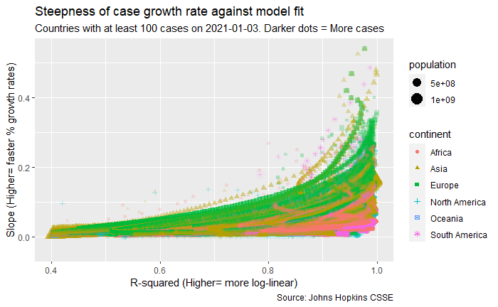

```r
stats_df_to_use %>%
#  filter(last_date %in% c(ymd("2020-03-01"), today())) %>%
  filter(!is.na(continent)) %>%
  ggplot(aes(x = r_squared, y = slope, colour = continent, size = population, shape = continent, alpha = log(num_cases))) +
  geom_point() +
  scale_alpha(guide = "none") +
#  theme(legend.position = "none") +
  scale_x_continuous(limits = c(0.4, 1.0)) +
#  facet_wrap(~last_date) +
#  geom_text_repel(aes(label = country), alpha = 1) +
  labs(
    x = "R-squared (Higher= more log-linear)",
    y = "Slope (Higher= faster % growth rates)",
    title = "Steepness of case growth rate against model fit",
    subtitle = glue::glue("Countries with at least {min_cases} cases on {today()}. Darker dots = More cases"),
    caption = "Source: Johns Hopkins CSSE"
  )
```

```r
# ggsave(here("figures", "rate_of_increase_against_model_fit.png"), height = 20, width = 20, units = "cm", dpi = 300)
```

That all works, now to add last_date as a frame

```r
fig_to_animate <-
  stats_df_to_use %>%
  mutate(
    country_label = ifelse(population >= 10^7, country, NA)
  ) %>%
    filter(!is.na(continent)) %>%
    ggplot(aes(x = r_squared, y = slope, colour = continent, size = population, shape = continent, alpha = log(num_cases))) +
    geom_point() +
    scale_alpha(guide = "none") +
    scale_size(guide = "none") +
  #  theme(legend.position = "none") +
    scale_x_continuous(limits = c(0.4, 1.0)) +
  #  facet_wrap(~last_date) +
  geom_text(aes(label = country_label), alpha = 1, colour = "black") +
    labs(
      x = "R-squared (Higher= more log-linear)",
      y = "Slope (Higher= faster % growth rates)",
      title = "Steepness of case growth rate against model fit on {frame_time}",
      subtitle = glue::glue("Countries with at least {min_cases} confirmed cases. Darker dots = More cases"),
      caption = "Source: Johns Hopkins CSSE"
    ) +
    transition_time(
      last_date
    ) +
    # transition_states(
    #   last_date,
    #   transition_length = 2,
    #   state_length = 10
    # ) +
    # transition_components(
    #   last_date,
    #   enter_length = 5,
    #   exit_length = 5
    # ) +
    ease_aes('cubic-in-out')
```

```r
animate(
  fig_to_animate,
  start_pause = 20,
  end_pause = 20,
  fps = 10,
  nframes = 300,
  height = 700, width = 700
)
```

[output not shown]

[output cut: 61 more lines]

[output not shown]

[output cut: 290 more lines]

```r
anim_save(here("figures", "linearity_growth_animation.gif"))
```

[output not shown]